# Seattle Pet License Data

In January of this year, Seattle released a [list](https://data.seattle.gov/Community/Seattle-Pet-Licenses/jguv-t9rb) of active/current pet licenses in the city.

For each of the 66,042 pets in the list we have the following data:

- Liscense Issue Date
- License Number
- Animal's Name
- Species
- Primary Breed
- Secondary Breed
- ZIP Code

The [data.seattle.gov](https://data.seattle.gov/Community/Seattle-Pet-Licenses/jguv-t9rb) website actually makes it fairly easy to explore, filter, and plot the data. Given that the only quantitative data we have are the License Number and zip code, however, the plots you can make online are a bit limited. Luckily, the dataset is easily downloaded as a `csv` file.

# Pet name word clouds sorted by breed

When I intially browsed the data online, I came across a Pug named Franklin Tucker. I thought this was a hilarious name for a Pug and it gave me the idea to create word clouds of dog names separated by breed. These word clouds would provide a fun way to look at the most common name for a given breed of dog. To make these word clouds, I used the [word cloud](https://github.com/amueller/word_cloud) package.

```python
#Import the usual stuff
import numpy as np
from PIL import Image
from os import path
import matplotlib.pyplot as plt
import random
import pandas as pd
from wordcloud import WordCloud, STOPWORDS
```

# Create a pandas DataFrame

The data are easily read into a dataframe given that we were able to download them as a `csv` file. I like using pandas for this sort of thing because it makes filtering the data on single or multiple columns extremely easy.

```python
pet_data = pd.read_csv('../data/Seattle_Pet_Licenses.csv',index_col=None)
```

One quick way to split the dataframe into groups is using the pandas `groupby` function.

```python
breed_groups = pet_data.groupby(['Primary Breed']).groups
```

`breed_groups` is now a dictionary whose keys are each of the Primary Breeds avaialbe in the original data, and each key corresponds to a list of index values into `pet_data`. Let's see how many different breeds are represented in the data.

```python
print (len(breed_groups))
```

```
323
```

Let's also print each breed and the number of pets that match that breed. This highlights how we can use the results of the `groupby` function to slice the original data.

```python
for breed in breed_groups.keys():
    print (breed,len(pet_data.iloc[breed_groups[breed]]))
```

```
Abyssinian 58
Affenpinscher 8
Afghan Hound 15
Akbash 3
Akita 74
Alapaha Blue Blood Bulldog 1
Alaskan Husky 52
Alaskan Klee Kai 16
Alaskan Malamute 128
American Bandogge Mastiff 3
American Blue Heeler 26
American Bobtail 4
American Curl 5
American Eskimo 142
American Indian Dog 2
American Shorthair 992
American Wirehair 2
Anatolian Shepherd 17
Angora 10
Appenzeller Sennenhunde 1
Argentine Dogo 9
Asian Shorthair 5
Australian Cattle Dog 728
Australian Kelpie 58
Australian Shepherd 1184
Australian Shepherd, Miniature 116
Azores Cattle Dog 1
Balinese 40
Barbet 1
Basenji 140
Basset Hound 181
Beagle 744
Bearded Collie 23
Beauceron 6
Belgian Malinois 61
Belgian Sheepdog 23
Belgian Tervuren 24
Bengal 98
Bernese Mountain Dog 228
Bichon Frise 360
```

[output cut: 268 more lines]

```
Thai Ridgeback 2
Tibetan Mastiff 11
Tiffany 4
Tonkinese 13
Toyger 4
Turkish Angora 5
Turkish Van 17
Vizsla, Smooth Haired 197
Vizsla, Wire Haired 1
Weimaraner 140
Welsh Corgi, Cardigan 270
Welsh Corgi, Pembroke 372
Whippet 117
White Swiss Shepherd (Berger Blanc Suisse) 3
Xoloitzcuintli 795
```

Now we can easily grab all of the data for a certain breed of pet. As an example let's grab the golden retrievers.

```python
golden_df = pet_data.iloc[breed_groups['Retriever, Golden']]
golden_df.head()
```

|  | License Issue Date | License Number | Animal's Name | Species | Primary Breed | Secondary Breed | ZIP Code |
| --- | --- | --- | --- | --- | --- | --- | --- |
| 2 | January 20 2006 | 29654 | Ginger | Dog | Retriever, Golden | Retriever, Labrador | 98117 |
| 4 | August 04 2006 | 729899 | Addy | Dog | Retriever, Golden | NaN | 98105 |
| 23 | March 18 2010 | 132643 | Nugget | Dog | Retriever, Golden | NaN | 98104 |
| 44 | December 29 2012 | 25863 | Spencer | Dog | Retriever, Golden | Poodle, Standard | 98107 |
| 65 | May 29 2013 | S111409 | Romeo | Dog | Retriever, Golden | NaN | 98144 |

You could also use `groupby` to group by Primary Breed and Zip Code. This would give you a quick way to look up how prevalent a breed in a given area.

```python
breed_groups = pet_data.groupby(['Primary Breed', 'ZIP Code']).groups
```

As an example lets look at all of the Standard Smooth Haired Dachshunds that live in the 98115 ZIP code.

```python
greenlake_sausages = pet_data.iloc[breed_groups['Dachshund, Standard Smooth Haired','98115']]
greenlake_sausages
```

|  | License Issue Date | License Number | Animal's Name | Species | Primary Breed | Secondary Breed | ZIP Code |
| --- | --- | --- | --- | --- | --- | --- | --- |
| 1239 | December 18 2014 | 946173 | Deiter | Dog | Dachshund, Standard Smooth Haired | NaN | 98115 |
| 2382 | December 26 2014 | 903321 | Chai | Dog | Dachshund, Standard Smooth Haired | Terrier | 98115 |
| 4454 | March 17 2015 | 132145 | Cooper | Dog | Dachshund, Standard Smooth Haired | NaN | 98115 |
| 8806 | April 17 2015 | 212877 | Rosetta | Dog | Dachshund, Standard Smooth Haired | NaN | 98115 |
| 9453 | June 22 2015 | 360228 | Jax | Dog | Dachshund, Standard Smooth Haired | Chihuahua, Short Coat | 98115 |
| 10963 | January 13 2015 | 959613 | Winnie | Dog | Dachshund, Standard Smooth Haired | NaN | 98115 |
| 11725 | January 13 2015 | 29840 | Foxy | Dog | Dachshund, Standard Smooth Haired | NaN | 98115 |
| 12497 | February 19 2015 | 85453 | Ivy | Dog | Dachshund, Standard Smooth Haired | Mix | 98115 |
| 13229 | April 10 2015 | 142889 | Caramel | Dog | Dachshund, Standard Smooth Haired | NaN | 98115 |
| 13372 | April 21 2015 | 84783 | Widget | Dog | Dachshund, Standard Smooth Haired | NaN | 98115 |
| 20339 | December 12 2015 | 828848 | Rusty | Dog | Dachshund, Standard Smooth Haired | NaN | 98115 |
| 20497 | December 08 2015 | 958028 | Winston | Dog | Dachshund, Standard Smooth Haired | NaN | 98115 |
| 21341 | August 06 2015 | 582297 | Tigerlily | Dog | Dachshund, Standard Smooth Haired | NaN | 98115 |
| 25183 | November 10 2015 | 904678 | Jax | Dog | Dachshund, Standard Smooth Haired | NaN | 98115 |
| 25944 | July 20 2015 | 29480 | Tina | Dog | Dachshund, Standard Smooth Haired | Terrier | 98115 |
| 28107 | August 27 2015 | S103067 | Penny | Dog | Dachshund, Standard Smooth Haired | Italian Greyhound | 98115 |
| 28273 | September 04 2015 | S103211 | Ziva | Dog | Dachshund, Standard Smooth Haired | Beagle | 98115 |
| 31708 | December 08 2015 | S108631 | Ruby | Dog | Dachshund, Standard Smooth Haired | Chihuahua, Short Coat | 98115 |
| 32906 | February 13 2016 | 9765 | BeBop | Dog | Dachshund, Standard Smooth Haired | NaN | 98115 |
| 36001 | February 16 2016 | 80352 | Yoshi | Dog | Dachshund, Standard Smooth Haired | NaN | 98115 |
| 36630 | February 06 2016 | 26015 | Harley | Dog | Dachshund, Standard Smooth Haired | NaN | 98115 |
| 36878 | February 13 2016 | 441122 | Amexia | Dog | Dachshund, Standard Smooth Haired | Retriever, Labrador | 98115 |
| 37913 | March 26 2016 | 582491 | Hamlet | Dog | Dachshund, Standard Smooth Haired | NaN | 98115 |
| 38142 | April 21 2016 | 213998 | Dozer | Dog | Dachshund, Standard Smooth Haired | Mix | 98115 |
| 38254 | May 10 2016 | 281732 | AnnaBelle | Dog | Dachshund, Standard Smooth Haired | Chihuahua, Short Coat | 98115 |
| 41734 | January 29 2016 | 28744 | Louis Jadot | Dog | Dachshund, Standard Smooth Haired | NaN | 98115 |
| 43950 | February 23 2016 | S111956 | Bentley Halterman | Dog | Dachshund, Standard Smooth Haired | NaN | 98115 |
| 48320 | November 15 2016 | 950236 | Lola | Dog | Dachshund, Standard Smooth Haired | NaN | 98115 |
| 48457 | October 25 2016 | 127047 | Trixie | Dog | Dachshund, Standard Smooth Haired | NaN | 98115 |
| 50211 | July 07 2016 | 282935 | Zach | Dog | Dachshund, Standard Smooth Haired | Terrier, Yorkshire | 98115 |
| 52508 | October 17 2016 | 727134 | Bella | Dog | Dachshund, Standard Smooth Haired | NaN | 98115 |
| 55295 | August 23 2016 | 586751 | Ty | Dog | Dachshund, Standard Smooth Haired | Mix | 98115 |
| 58141 | September 02 2016 | S118897 | Tweak | Dog | Dachshund, Standard Smooth Haired | NaN | 98115 |
| 59892 | August 25 2016 | S120369 | Molly | Dog | Dachshund, Standard Smooth Haired | Chihuahua, Short Coat | 98115 |
| 63152 | December 24 2016 | 946173 | Deiter | Dog | Dachshund, Standard Smooth Haired | NaN | 98115 |
| 63379 | December 14 2016 | 827371 | Fanny | Dog | Dachshund, Standard Smooth Haired | NaN | 98115 |
| 63986 | November 23 2016 | 903321 | Chai | Dog | Dachshund, Standard Smooth Haired | Terrier | 98115 |
| 65968 | December 28 2016 | S125251 | Max | Dog | Dachshund, Standard Smooth Haired | Chihuahua, Short Coat | 98115 |

# Creating the word clouds

Below is a function that will pull out the data for a user given Primary Breed and return a word cloud. In this function I illustrate another way to slice the data using the pandas `str.contains()` function over the Primary Breed coulumn.

This has the benefit of letting us slice the data with very specific or more general breed names (e.g Terrier vs Terrier, Jack Russell). Using the `str.contains()` function, it is easy to separate or combine the two related breeds.

```python
all_terrier_df = pet_data[pet_data['Primary Breed'].str.contains('Terrier') == True]
jack_terrier_df = pet_data[pet_data['Primary Breed'].str.contains('Terrier, Jack Russell') == True]
all_terrier_df.tail()
```

|  | License Issue Date | License Number | Animal's Name | Species | Primary Breed | Secondary Breed | ZIP Code |
| --- | --- | --- | --- | --- | --- | --- | --- |
| 65987 | December 29 2016 | S125242 | Walter | Dog | Terrier, Soft Coated Wheaten | NaN | 98103 |
| 66009 | December 30 2016 | S125248 | Sousa | Dog | Terrier, Boston | NaN | 98117 |
| 66016 | December 30 2016 | S125203 | Buddy | Dog | Terrier, Russell | NaN | 98177 |
| 66018 | December 30 2016 | S125221 | Benjamón | Dog | Terrier | Chihuahua, Short Coat | 98109 |
| 66039 | December 05 2016 | S101614 | Sammy | Dog | Terrier | Maltese | 98105 |

```python
jack_terrier_df.head()
```

|  | License Issue Date | License Number | Animal's Name | Species | Primary Breed | Secondary Breed | ZIP Code |
| --- | --- | --- | --- | --- | --- | --- | --- |
| 90 | August 11 2013 | 951542 | Mickie | Dog | Terrier, Jack Russell | NaN | 98105 |
| 282 | August 11 2013 | 951542 | Mickie | Dog | Terrier, Jack Russell | NaN | 98105 |
| 809 | April 03 2014 | 140471 | NaN | Dog | Terrier, Jack Russell | Mix | 98119 |
| 825 | April 12 2014 | 214579 | Sammy | Dog | Terrier, Jack Russell | Basset Hound | 98177 |
| 897 | June 05 2014 | 356422 | Jazzie | Dog | Terrier, Jack Russell | Terrier, Rat | 98104 |

The `breed_cloud` function below returns a word cloud based on a user-given `breed` name. At a minimum, the user must provide a pandas dataframe containing the pet license data and a `breed` name. The user may optionally pass this function `breed2` and `mask` arguments. The `breed2` option is used to provide a Secondary Breed (e.g `breed` = 'Terrier, Jack Russel',`breed2` = 'Terrier, Rat'). The `mask` argument is a boolean. If `mask` is set to `True`, the user must also provide the file name of the `mask_image`. This option is used if you want to change the shape of your word cloud based to match the given `mask_image`.

```python
def breed_cloud(all_pets_df,breed,**kwargs):
    try:
        if 'breed2' in kwargs.keys():
            breed_df = all_pets_df[(all_pets_df['Primary Breed'].str.contains(breed) == True) &
                                   (all_pets_df['Secondary Breed'].str.contains(kwargs[breed2]) == True)]
        else:
            breed_df = all_pets_df[(all_pets_df['Primary Breed'].str.contains(breed) == True)]
        breed_names = list(breed_df["Animal's Name"].dropna())
        all_name_string = ' '
        for i, name in enumerate(breed_names):
            all_name_string += str(name)+' '
        try:
            if kwargs['mask'] == True:
                try:
                    mask_image = kwargs['mask_image']
                    breed_mask = np.array(Image.open(mask_image))
                except KeyError:
                    print ('If mask is True must provide mask image')
                wc = WordCloud(background_color="white",max_words=100,
                max_font_size=75,mask=breed_mask).generate(all_name_string)
        except KeyError:
            wc = WordCloud(background_color="white",max_words=100,
                           max_font_size=75).generate(all_name_string)
        return wc
    except ValueError:
        print ('Maybe that breed is not in the data?')
```

# For our first example, let's make a word cloud for the Dachshunds

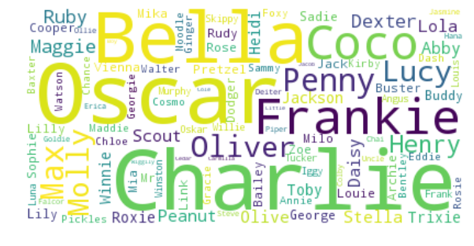

```python
wc_dachshund = breed_cloud(pet_data,'Dachshund')
plt.figure(figsize=(10,10))
plt.imshow(wc_dachshund, interpolation='bilinear')
plt.axis("off")
plt.show()
```

Unsuprisingly, Oscar is a popular name for Dachshunds. Given that Dachshunds have such a distinctive profile, they also provide a good example of the `mask` option.

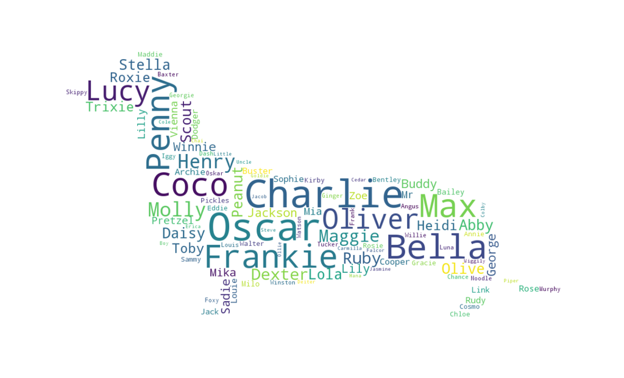

```python
wc_dachshund = breed_cloud(pet_data,'Dachshund',mask=True,mask_image='dach.png')
plt.figure(figsize=(20,20))
plt.imshow(wc_dachshund, interpolation='bilinear')
plt.axis("off")
plt.show()
```

# As another fun example, let's look at the differences between American, French, and Engish bulldogs

```python
wc_american = breed_cloud(pet_data,'Bulldog, American')
wc_french = breed_cloud(pet_data,'Bulldog, French')
wc_english = breed_cloud(pet_data,'Bulldog, English')
```

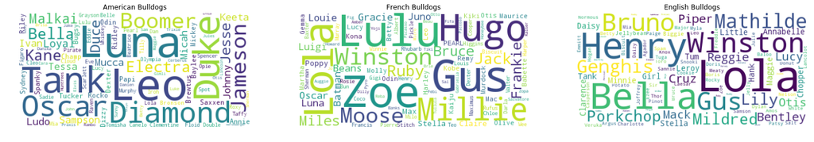

```python
plt.figure(figsize=(25,25))
ax1 = plt.subplot(131)
ax2 = plt.subplot(132)
ax3 = plt.subplot(133)
ax1.imshow(wc_american, interpolation='bilinear')
ax1.set_title('American Bulldogs')
ax2.imshow(wc_french, interpolation='bilinear')
ax2.set_title('French Bulldogs')
ax3.imshow(wc_english, interpolation='bilinear')
ax3.set_title('English Bulldogs')
ax1.axis("off")
ax2.axis("off")
ax3.axis("off")
plt.show()
```